# Module 8. Generalized linear mixed models

Slides

# From GLMs to GLMMs

## A GLMM adds random effects to a generalized linear model

$$g\{E(Y_{ij} \mid \mathbf{b}_i)\} = \mathbf{x}_{ij}^\top\boldsymbol\beta + \mathbf{z}_{ij}^\top\mathbf{b}_i,
\qquad \mathbf{b}_i \sim N(\mathbf{0}, G)$$

- Given $\mathbf{b}_i$: independent binomial, Poisson or negative binomial outcomes.
- Correlation within a participant comes from the shared $\mathbf{b}_i$.
- Coefficients are **subject-specific (conditional)**: they compare situations for the same participant.

## The likelihood needs an integral over the random effects

$$L_i = \int \prod_{j} f(y_{ij} \mid \mathbf{b}_i)\, \varphi(\mathbf{b}_i; G)\, d\mathbf{b}_i$$

- No closed form for non-normal outcomes: software approximates it.
- **Laplace**: a normal approximation around the peak (`nAGQ = 1`, `glmmTMB`).
- **Adaptive Gauss–Hermite quadrature**: a weighted sum over several points (`glmer`, random intercept only).
- Matters most for **binary data, few observations per participant, large $\tau_0$**.

# Logistic mixed models for CLEAR

## The model for CLEAR

$$\operatorname{logit} P(Y_{ij}=1 \mid b_{0i}) = \beta_0 + \beta_1 t_{ij} + \beta_2\text{Active}_i + \beta_3 t_{ij}\text{Active}_i + b_{0i},\quad b_{0i}\sim N(0,\tau_0^2)$$

```r
glmm_clear <- glmer(itch ~ week * arm + (1 | id), data = clear,
                    family = binomial, nAGQ = 25)
```

- No residual variance: for binary data it is fixed by the probability.
- Truth (simulated data): $\beta_1 = -0.06$, $\beta_3 = -0.16$, $\tau_0 = 2.0$.

## Laplace underestimates the random-intercept SD here

|  | Method | Intercept | week | armActive | week:armActive | SD b |
| --- | --- | --- | --- | --- | --- | --- |
| (Intercept) | glmer, nAGQ = 1 | 0.1376 | -0.0964 | -0.1172 | -0.1270 | 1.668 |
| (Intercept)1 | glmer, nAGQ = 5 | 0.1332 | -0.0959 | -0.1112 | -0.1296 | 1.749 |
| (Intercept)2 | glmer, nAGQ = 10 | 0.1331 | -0.0959 | -0.1128 | -0.1299 | 1.760 |
| (Intercept)3 | glmer, nAGQ = 25 | 0.1331 | -0.0959 | -0.1128 | -0.1299 | 1.760 |
| (Intercept)4 | glmmTMB (Laplace) | 0.1375 | -0.0964 | -0.1172 | -0.1270 | 1.668 |

- Results stabilise by 10 quadrature points; use AGQ for a binary random-intercept model.

## Coefficients are within-participant odds ratios

| Term | Odds ratio | Lower | Upper | p |
| --- | --- | --- | --- | --- |
| (Intercept) | 1.142 | 0.695 | 1.877 | 0.600 |
| week | 0.909 | 0.858 | 0.962 | 0.001 |
| armActive | 0.893 | 0.438 | 1.820 | 0.756 |
| week:armActive | 0.878 | 0.804 | 0.960 | 0.004 |

- For a given participant: odds of itch $\times$ 0.909 per week on placebo, a further $\times$ 0.878 per week on active.
- $\hat\tau_0$ = 1.76: latent-scale ICC 0.49.

## DHARMa: simulation-based residuals for any GLMM

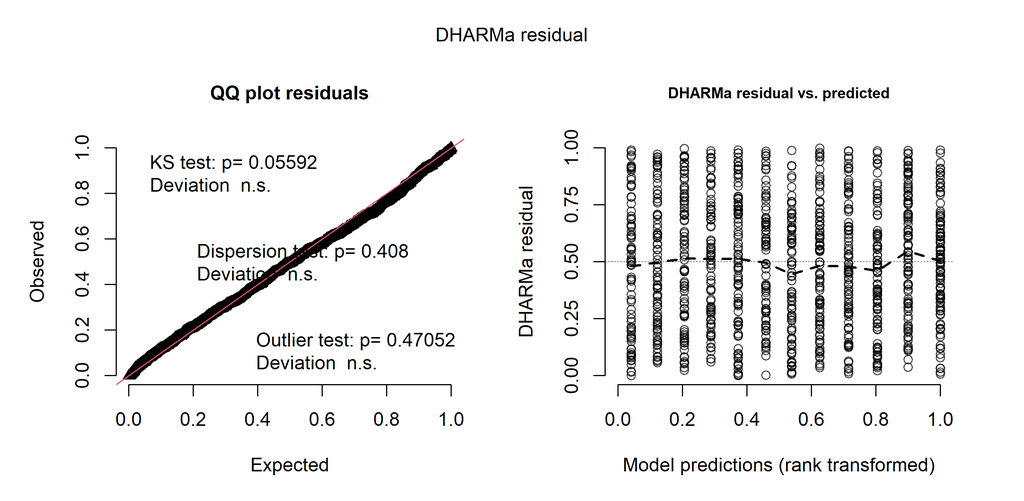

## Try it

Workbook **Exercises 1 and 2**: fit the CLEAR GLMM with Laplace and AGQ, interpret the coefficients, and check it with DHARMa.

# Why GLMM and GEE coefficients differ

## The average of steep curves is a flatter curve

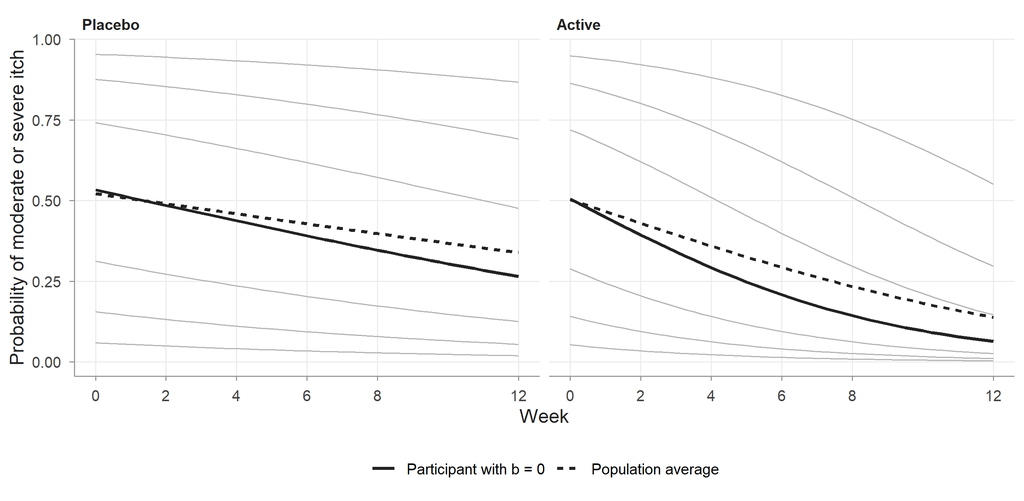

## The attenuation approximation

$$\boldsymbol\beta_M \approx \frac{\boldsymbol\beta_C}{\sqrt{1 + 0.346\,\tau_0^2}}$$

- $0.346 = \{16\sqrt{3}/(15\pi)\}^2$; logit link, normal random intercept (Zeger et al. 1988; Neuhaus et al. 1991).
- $\tau_0 = 1$: factor 0.86; $\tau_0 = 2$: factor 0.65.
- CLEAR: $\hat\tau_0$ = 1.76, factor 0.695.

## On CLEAR the GLMM-implied marginal effects match GEE

|  | GLMM | Approx. marginal | Exact marginal | GEE | Truth (cond.) | Truth (approx. marg.) |
| --- | --- | --- | --- | --- | --- | --- |
| (Intercept) | 0.1331 | 0.0924 | 0.0875 | 0.0849 | 0.00 | 0.0000 |
| week | -0.0959 | -0.0666 | -0.0628 | -0.0634 | -0.06 | -0.0389 |
| armActive | -0.1128 | -0.0784 | -0.0637 | -0.0634 | 0.00 | 0.0000 |
| week:armActive | -0.1299 | -0.0902 | -0.0895 | -0.0844 | -0.16 | -0.1036 |

## Which effect is the right target?

- **Population-average**: public-health impact, proportions of responders, regulatory endpoints.
- **Subject-specific**: change within individuals, individual prediction, mechanisms.
- State the estimand in the protocol; do not compare across kinds.
- A GLMM can give both: conditional coefficients, and marginal summaries by integration.

## Try it

Workbook **Exercise 3**: compute the attenuation factor and the exact marginal coefficients for CLEAR and compare with GEE.

# Predicted probabilities and effect summaries

## Conditional at $b = 0$ versus population-averaged

| Arm | Week | P at b = 0 | Population P | Lower | Upper |
| --- | --- | --- | --- | --- | --- |
| Placebo | 0 | 0.533 | 0.522 | 0.438 | 0.600 |
| Active | 0 | 0.505 | 0.503 | 0.422 | 0.585 |
| Placebo | 12 | 0.265 | 0.339 | 0.255 | 0.431 |
| Active | 12 | 0.064 | 0.139 | 0.087 | 0.210 |

Marginal risk difference at week 12: -0.200 (95% interval -0.303 to -0.091).

## Uncertainty for marginal summaries: draw, integrate, summarise

```r
V_joint <- 2 * solve(glmm_clear@optinfo$derivs$Hessian)   # (theta, beta)
draws <- MASS::mvrnorm(4000, c(getME(glmm_clear, "theta"), fixef(glmm_clear)),
                       V_joint)
marg <- apply(draws, 1, function(d) marginal_p(Xp %*% d[-1], abs(d[1])))
quantile(marg[4, ] - marg[3, ], c(0.025, 0.975))           # risk difference
```

- Parametric bootstrap (`bootMer`) is the more thorough alternative.
- `emmeans` bias adjustment is a second-order approximation: here it overstates the placebo proportion.

## Try it

Workbook **Exercise 4**: compute population-averaged probabilities, a risk difference and a risk ratio with intervals.

# Count outcomes: DIARY

## Poisson and negative binomial GLMMs with an offset

$$\log E(Y_{ij} \mid b_{0i}) = \log(\text{days}_{ij}) + \beta_0 + \beta_1\text{post}_{ij} + \beta_2\text{Active}_i + \beta_3\text{post}_{ij}\text{Active}_i + b_{0i}$$

```r
nb_glmm <- glmmTMB(migraine_days ~ post * arm + offset(log(days)) + (1 | id),
                   data = diary, family = nbinom2)   # Var = mu + mu^2 / theta
```

- Log link with random intercept: conditional and marginal **rate ratios are equal**; intercepts differ by $\tau_0^2/2$.

## Overdispersion: the random intercept is not enough

| Model | Pearson ratio | DHARMa dispersion | DHARMa zeros obs/sim | AIC |
| --- | --- | --- | --- | --- |
| Poisson GLMM | 1.58 | 1.51 | 1.57 | 5065 |
| NB GLMM | 0.85 | 1.15 | 1.06 | 4827 |
| ZINB GLMM | NA | NA | NA | 4829 |

- Poisson: treatment effect -0.227 (SE 0.080); NB: -0.197 (SE 0.120).

## Apparent zero inflation was overdispersion

- Poisson GLMM: 1.57 times the expected zeros ($p < 0.001$).
- NB GLMM: 1.06 times ($p$ = 0.57).
- ZINB: zero-inflation log-odds -18.6, same log-likelihood, higher AIC.
- Truth: no excess zeros. Test zero inflation **against NB**, and only with a substantive reason.

## DHARMa residuals: Poisson versus negative binomial

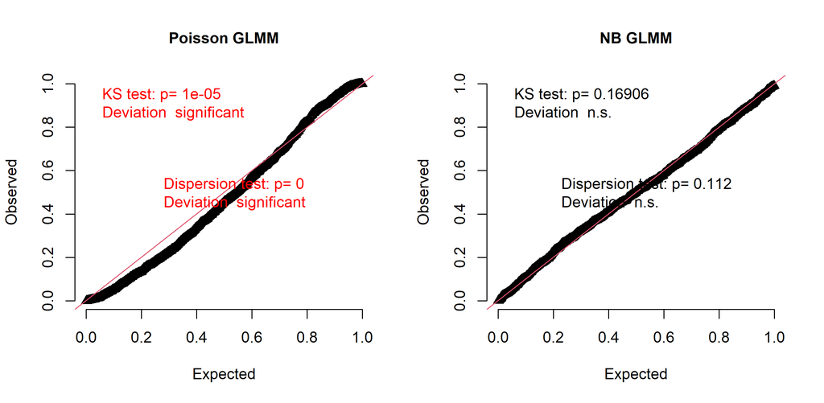

## Rate ratios and expected migraine days per 28 days

- Ratio of rate ratios: 0.82 (95% CI 0.65 to 1.04); truth 0.67.
- Per 28 days during treatment, participant with $b = 0$: 4.2 (placebo), 3.1 (active).
- Population mean (`bias.adjust = TRUE`, exact for log link): 4.8 and 3.5.

```r
emmeans(nb_glmm, ~ arm | post, offset = log(28), type = "response",
        bias.adjust = TRUE, sigma = sigma_b)
```

## Try it

Workbook **Exercises 5 and 6**: Poisson versus negative binomial GLMM for DIARY, overdispersion and zero-inflation checks, rate ratios and expected counts.

# Summary

## Key messages

- GLMM coefficients are **conditional**: within-participant comparisons.
- Logistic GLMM and GEE coefficients differ by about $\sqrt{1 + 0.346\,\tau_0^2}$; compare like with like.
- Check quadrature for binary GLMMs (Laplace vs AGQ).
- Report **probabilities, risk differences, expected counts**, stating conditional or marginal.
- Counts: offset, overdispersion (NB), zero inflation only when justified; check with **DHARMa**.

Neuhaus, John M., John D. Kalbfleisch, and Walter W. Hauck. 1991. ‘A Comparison of Cluster-Specific and Population-Averaged Approaches for Analyzing Correlated Binary Data’. *International Statistical Review* 59 (1): 25–35. https://doi.org/10.2307/1403572.

Zeger, Scott L., Kung-Yee Liang, and Paul S. Albert. 1988. ‘Models for Longitudinal Data: A Generalized Estimating Equation Approach’. *Biometrics* 44 (4): 1049–60. https://doi.org/10.2307/2531734.